# PDB Exercise 2: adjust response rates

Stas Kolenikov

7/22/2021

## Libraries

```r
libs <- c('tidyverse', 'here', 'optimx', 'janitor', 'knitr', 'kableExtra')
for( l in libs) {
  library(l, character.only = TRUE)
}
#' Format a table for HTML output with striped rows if HTML, or simply display if interactive
#' @param   x an input table
#' @return  a formatted table to be displayed if necessary
#' @export
maybe_kable <- function(x, bg='white') {
  # x is likely a data frame or a tibble
  if (!is.data.frame(x)) return(x)
  else {
    if (interactive()) return(x)
    else {
      # make it a nice kable
      x %>%
        knitr::kable(format.args = list(big.mark=" ")) %>%
        kableExtra::row_spec(0,color='white',background="#48A9C5") %>%
        row_spec(1:nrow(x), color=ifelse(bg=='black', '#d0d3d4', 'black') ) -> tx # header colors
      if (nrow(x)>1) { # alternating rows
        if (bg=='white') {
          tx %>% row_spec(seq(from=2,to=nrow(x),by=2), background = '#dfd1a7') -> tx
        } else if (bg=='black') {
          tx %>% row_spec(seq(from=2,to=nrow(x),by=2), background = '#789d4a') -> tx
        }
      }
      return(tx)
    }
  }
}
#' compute penalized design effect to optimize the stratified sample
#'
#' @param above_black   % cutoff for the high black concentration stratum
#' @param above_hisp    % cutoff for the high Hispanic concentration stratum
#' @param above_minor   % cutoff for the high minority concentration
#' @param lop1          log odds ratio of stratum 1 vs. stratum 4
#' @param lop2          log odds ratio of stratum 2 vs. stratum 4
#' @param lop3          log odds ratio of stratum 3 vs. stratum 4
#' @param target_n      target sample size (inherited from environment)
#' @param target_black  target sample size (inherited from environment)
#' @param target_hisp   target sample size (inherited from environment)
#' @param minsize       minimum number of tracts per stratum (default 30)
#' @param data          the sampling frame data source, PDB_CT in reality
#' @param verbose       additional output is provided (off by default)
#' @return              A list with the following components:
#'
#'                      all numeric inputs passed through as is
#'                      transformed strata proportions
#'                      \code{deff}: unequal weighting design effect
#'                      \code{fobj}: design effect with penalties
#'                      \code{sample_design}: the data frame with the resulting design
#' @example
#'
#'                      High density strata: above 40% minorities; white stratum: < 30%
#'                      same size strata, provide all output
#'                      design4_arr(0.4, 0.4, 0.3, -0.5, -0.3, -0.3, verbose=TRUE)
#' @export
design4_arr <- function(
  above_black, above_hisp, above_minor,
  lop1, lop2, lop3,
  arr = 0.15,
  minsize = 30,
  data = PDB_CT,
  # target_n = target_n, target_black=target_black, target_hisp=target_hisp,
  verbose = FALSE) {

  if (above_black<0 | above_black > 1 | above_hisp<0 | above_hisp >1 |
      above_minor<0 | above_minor > 1 ) return( list(fobj=1e20) )

  if (!between(arr,0,1)) {
    stop("Anticipated response rate must be between 0 and 1, vs.", arr)
  }

  # strata proportions
  p1 <- exp(lop1)/(exp(lop1)+exp(lop2)+exp(lop3)+1)
  p2 <- exp(lop2)/(exp(lop1)+exp(lop2)+exp(lop3)+1)
  p3 <- exp(lop3)/(exp(lop1)+exp(lop2)+exp(lop3)+1)
  p4 <- exp(0)/(exp(lop1)+exp(lop2)+exp(lop3)+1)
  if ( abs( p1 + p2 + p3 + p4 - 1 ) > 1e-5 ) {
    stop("Strata proportions are misformed: ", paste(p1,p2,p3,p4, collapse=", "))
  }

  # stratify
  data %>% mutate(strata4 = case_when(
    pct_NH_black_alone > above_black ~ 1,
    pct_hisp  > above_hisp  ~ 2,
    pct_minority > above_minor ~ 3,
    TRUE ~ 4
  ) ) %>%
  select(GIDTR,Tot_Population_ACS_15_19,NH_Blk_alone_ACS_15_19,
         Hispanic_ACS_15_19,r2,strata4) -> data4

  # first pass at sample size
  data4 %>% group_by(strata4) %>%
    summarize(
      tracts = n(),
      pop   = sum(Tot_Population_ACS_15_19),
      black = sum(NH_Blk_alone_ACS_15_19),
      hisp  = sum(Hispanic_ACS_15_19),
      RR    = weighted.mean(x=r2, w=Tot_Population_ACS_15_19, na.rm=TRUE) ) %>%
    mutate(
      n1_field = case_when(
        strata4 == 1 ~ 1000*p1,
        strata4 == 2 ~ 1000*p2,
        strata4 == 3 ~ 1000*p3,
        strata4 == 4 ~ 1000*p4
      ),
      n1_total = (n1_field * RR),
      n1_black = (n1_field * RR * black / pop),
      n1_hisp  = (n1_field * RR * hisp / pop)
    ) %>% ungroup() -> data4_sample1

  n1 <- sum(data4_sample1$n1_total)

  if (verbose) {
    print(data4_sample1)
    print(n1)
    print(target_n)
  }

  # second pass at the sample size
  data4_sample1 %>% mutate(
    n2_field = n1_field * target_n/n1,
    n2_total = n2_field * RR,
    n2_black = n2_field * RR * black / pop,
    n2_hisp  = n2_field * RR * hisp / pop
  ) %>% select(-starts_with("n1_")) -> data4_sample
  if (is.na(sum(data4_sample$n2_total))) {
    print(data4_sample)
    stop("Total sample size does not match up: ", sum(data4_sample$n2_total) )
  }
  if( abs( sum(data4_sample$n2_total) - target_n ) > 1e-4 ) {
    print(data4_sample)
    stop("Total sample size does not match up: ", sum(data4_sample$n2_total) )
  }

  # DEFF
  data4_sample %>%
    mutate(weight=pop/n2_total) %>%
    summarise( n_wgt = sum(n2_total*weight),
               n_wgt2 = sum(n2_total*weight*weight),
               n = sum(n2_total) ) %>%
    mutate(UWE_DEFF = n_wgt2 * n / (n_wgt*n_wgt) ) %>%
    select(UWE_DEFF) %>% unlist() -> UWE_DEFF
  names(UWE_DEFF) <- ''

  # penalties
  fobj <- UWE_DEFF
  ### for missing the oversample targets
  fobj <- fobj + log( 1 + min( c( sum(data4_sample$n2_black)-target_black, 0 ) )^2 )
  fobj <- fobj + log( 1 + min( c( sum(data4_sample$n2_hisp) -target_hisp,  0 ) )^2 )

  ### for strata sizes that are too small
  for(i in 1:nrow(data4_sample)) {
    fobj <- fobj + log(1 + min( c(unlist(data4_sample[i,"tracts"])-minsize, 0) )^2 )
  }

  ### for absent strata
  fobj <- fobj + 5*(nrow(data4_sample)-4)^2

  if (is.na(fobj)) {
    print(c(  above_black, above_hisp, above_minor,
        lop1, lop2, lop3))
    print(data4_sample)
    stop("Invalid objective function value ", fobj )
  }

  # return
  rlist  <-       list(
        above_black = above_black,
        above_hisp  = above_hisp,
        above_minor = above_minor,
        n_total     = sum(data4_sample$n2_total),
        n_black     = sum(data4_sample$n2_black),
        n_hisp      = sum(data4_sample$n2_hisp),
        deff        = UWE_DEFF,
        p1          = p1,
        p2          = p2,
        p3          = p3,
        p4          = p4,
        fobj        = fobj,
        sample_design = (data4_sample %>% select( - starts_with('n1_')))
      )
  if (verbose) {
    print(data4_sample)
    print(rlist)
  }

  return( rlist )
}

#' wrapper around design4() that takes inputs as a vector
#' @param par   vector input of c(above_black, above_hisp, above_minor, lop1, lop2, lop3)
#' @return      the penalized deff / design4()$fobj
#' @export
design4_arr_opt <- function(par) {

  design4_return <- tryCatch( design4_arr(
    above_black = par[1], above_hisp=par[2], above_minor=par[3],
    lop1=par[4], lop2=par[5], lop3=par[6]
  )$fobj ,
    error = function(e) 1000
  )

  return(design4_return)
}
```

## PDB CT data

```r
read_csv(here('pdb','pdb2021trv3_ct.csv')) %>% mutate(
    pct_NH_black_alone = NH_Blk_alone_ACS_15_19 / Tot_Population_ACS_15_19,
    pct_hisp           = Hispanic_ACS_15_19 / Tot_Population_ACS_15_19,
    pct_minority       = pct_NH_black_alone + pct_hisp
  ) %>% filter(!is.na(Low_Response_Score)) -> PDB_CT
```

## Sample design targets

```r
target_n <- 2500
target_black <- 500
target_hisp <- 500
```

We need to create a sample of adults in the state of Connecticut, with the target of 2500, and oversample targets for racial/ethnic minorities:

- Black/African American: 500
- Hispanic: 500

## Sampling design foundation

Four strata:

1. high Black/AA: cutoff parameter for the census tracts with the highest concentration of NH Black
2. high Hispanic: cutoff parameter for the census tracts with the highest concentration of Hispanics that are not in strata 1
3. mixed minority: other tracts with moderate to high concentration of minorities
4. white: tracts with low density of NH Blacks and Hispanics

## Adjusting response rates

We are given the target of 15% anticipated response rate. I will adjust the rates given by the `Low_Response_Score` variable on the logit scale as follows. Denote the `Low_Response_Score` for tract `j` as `R_j`. Then we will have the following sequence of transformations:

$$R_j \rightarrow \Lambda_j = \ln \frac{R_j}{1-R_j} \rightarrow
\lambda_j = \Lambda_j+\alpha \rightarrow r_j = \frac{1}{1+\exp(-\lambda_j)}$$

The transformation parameter $\alpha$ needs to be chosen so that the overall response rate $\sum_j w_j r_j$ equals the target (here, $w_j$ is the population fraction in tract $j$, the ratio of `Total_Population_ACS_15_19` in the tract to the sum of that variable over the state.)

```r
# adjust the response rates on the log odds scale
PDB_CT$r2 <- 1 - PDB_CT$Low_Response_Score/100
# shift by -3
PDB_CT$r2 <- 1/(1+exp(-log(PDB_CT$r2/(1-PDB_CT$r2))+3))
k <- 0
while ( abs(
  PDB_CT %>% summarize(weighted.mean(x=r2, w=Tot_Population_ACS_15_19, na.rm=TRUE)) %>% unlist()
  - arr ) > 0.0001 ) {
  PDB_CT %>% mutate(
    r1 = r2,
    logit_rr = log(r1/(1-r1)),
    der      = logit_rr*(1-logit_rr),
    d_adj    = - (arr - sum(r1*Tot_Population_ACS_15_19)/sum(Tot_Population_ACS_15_19))
    /(sum(der*Tot_Population_ACS_15_19)/sum(Tot_Population_ACS_15_19)),
    r2       = 1/(1+exp(-logit_rr - d_adj))
  ) -> PDB_CT

  k <- k+1
  if ( k %% 50==0) {
    cat("Iteration ", k, ":\nAdjustment intercept = ", mean(PDB_CT$d_adj), "\n")
    # print(summary(PDB_CT$r2))
    cat("Weighted mean of RR: ",
        PDB_CT %>%
          summarize(RR1 = weighted.mean(x=r1, w=Tot_Population_ACS_15_19, na.rm=TRUE),
                    RR2 = weighted.mean(x=r2, w=Tot_Population_ACS_15_19, na.rm=TRUE) ) %>%
          unlist(),
        "\n"
    )
  }
}
```

```
## Iteration  50 :
## Adjustment intercept =  -0.001447546
## Weighted mean of RR:  0.1571363 0.1569487
## Iteration  100 :
## Adjustment intercept =  -0.0003871427
## Weighted mean of RR:  0.151979 0.1519302
## Iteration  150 :
## Adjustment intercept =  -0.0001112421
## Weighted mean of RR:  0.1505743 0.1505604
## Iteration  200 :
## Adjustment intercept =  -3.259638e-05
## Weighted mean of RR:  0.1501688 0.1501647
```

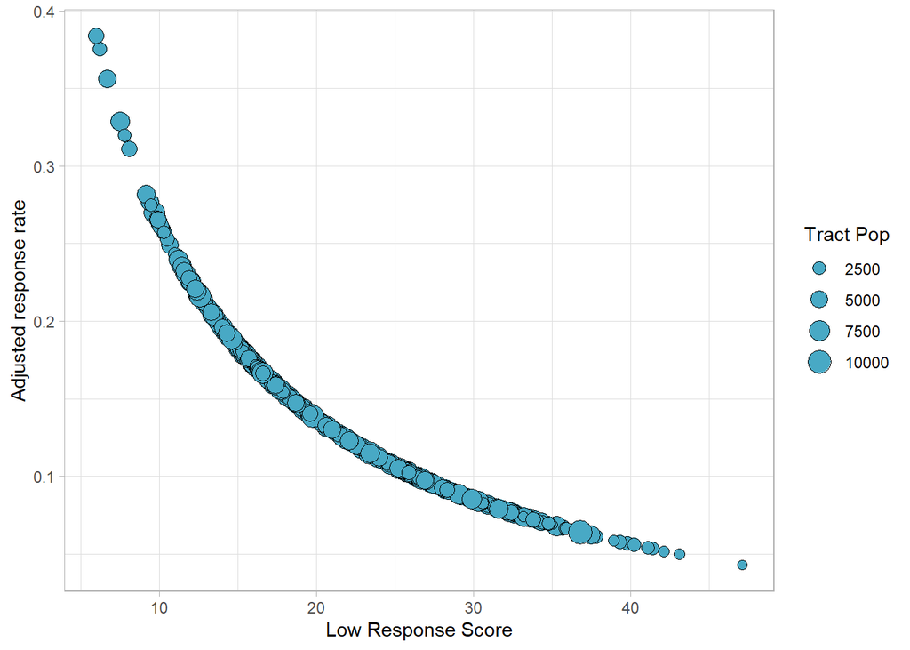

```r
ggplot(PDB_CT %>%
         rename(`Tract Pop`=Tot_Population_ACS_15_19) ) +
  geom_point(aes(y=r2,x=Low_Response_Score,
                 size=`Tract Pop`),
                 fill='#48A9C5', colour='black', shape=21) +
  ylab('Adjusted response rate') + xlab('Low Response Score') +
  theme_light()
```

## Optimization target

For the given sample size of 2500, we want to minimize the unequal weighting design effect $1+CV^2$.

## Optimization

The above function needs to be made compatible with `stats::optim()` and `library(optimx)`, which expect a function that accepts a vector of parameters, and returns a scalar value of the function to be optimized.

```r
design4_arr_opt(c(0.4,0.4,0.3,-0.5,-0.5,-0.5))
```

```
##
## 9.601587
```

Let us now try the different optimization routines and methods available.

## Stats (base R) package

### optim: BFGS

```r
bfgso_arr.time <- system.time(
  bfgso_arr <- optim(fn=design4_arr_opt,par=c(0.4,0.4,0.3,-0.4,-0.6,-0.6),method="BFGS"))
bfgso_arr
```

```
## $par
## [1]  0.4000000  0.5838811  0.6802662 -0.5386971 -0.3001677 -0.6934765
##
## $value
## [1] 1.53359
##
## $counts
## function gradient
##       76        7
##
## $convergence
## [1] 0
##
## $message
## NULL
```

The design effect is 1.5335899.

Optimization took 6.46 seconds and converged succesfully. The implied design is:

```r
bfgso_arr_design <- design4_arr(
  above_black=bfgso_arr$par[1],
  above_hisp =bfgso_arr$par[2],
  above_minor=bfgso_arr$par[3],
  minsize = 30,
  lop1=bfgso_arr$par[4],
  lop2=bfgso_arr$par[5],
  lop3=bfgso_arr$par[6])
bfgso_arr_design$sample_design %>%
  mutate(
    definition = case_when(
      strata4 == 1 ~ paste0("> ", round(bfgso_arr_design$above_black*100,2), "% NH Black"),
      strata4 == 2 ~ paste0("> ", round(bfgso_arr_design$above_hisp*100,2), "% Hisp"),
      strata4 == 3 ~ paste0("> ", round(bfgso_arr_design$above_minor*100,2), "% minority"),
      strata4 == 4 ~ "Mostly NH White"),
    rate_per1k = n2_field/pop*1000
  ) %>% select(strata4, definition, rate_per1k, tracts, starts_with("n2")) %>%
  mutate(across(where(is.numeric),round)) %>%
  janitor::adorn_totals("row") %>%
  maybe_kable()
```

strata4

definition

rate_per1k

tracts

n2_field

n2_total

n2_black

n2_hisp

1

> 40% NH Black

30

40

4 704

434

250

102

2

> 58.39% Hisp

52

34

5 972

442

72

292

3

> 68.03% minority

24

44

4 030

340

98

167

4

Mostly NH White

3

706

8 062

1 284

81

156

Total

109

824

22 768

2 500

501

717

The sampling rate of Hispanics can be reduced to improve the design effect.

### optim: Nelder-Mead

```r
( st_nm_arr.time <- system.time(
  st_nm_arr <- stats::optim(fn=design4_arr_opt,par=c(0.4,0.4,0.3,-0.5,-0.5,-0.5),method="Nelder-Mead",
  control=list(maxit=5000,trace=0))) )
```

```
##    user  system elapsed
##   35.64    0.13   36.28
```

```r
st_nm_arr
```

```
## $par
## [1]  0.4384431  0.4638448  0.4073424 -0.3744932 -0.5404186 -0.6303753
##
## $value
## [1] 1.270554
##
## $counts
## function gradient
##      733       NA
##
## $convergence
## [1] 0
##
## $message
## NULL
```

Optimization took 36.28 seconds and converged succesfully. The implied design is:

```r
st_nm_arr_design <- design4_arr(
  above_black=st_nm_arr$par[1],
  above_hisp =st_nm_arr$par[2],
  above_minor=st_nm_arr$par[3],
  lop1=st_nm_arr$par[4],
  lop2=st_nm_arr$par[5],
  lop3=st_nm_arr$par[6])
st_nm_arr_design$sample_design %>%
  mutate(
    definition = case_when(
      strata4 == 1 ~ paste0("> ", round(bfgso_arr_design$above_black*100,2), "% NH Black"),
      strata4 == 2 ~ paste0("> ", round(bfgso_arr_design$above_hisp*100,2), "% Hisp"),
      strata4 == 3 ~ paste0("> ", round(bfgso_arr_design$above_minor*100,2), "% minority"),
      strata4 == 4 ~ "Mostly NH White"),
    rate_per1k = n2_field/pop*1000
  ) %>% select(strata4, definition, rate_per1k, tracts, starts_with("n2")) %>%
  mutate(across(where(is.numeric),round)) %>%
  janitor::adorn_totals("row") %>%
  maybe_kable()
```

strata4

definition

rate_per1k

tracts

n2_field

n2_total

n2_black

n2_hisp

1

> 40% NH Black

37

34

5 133

484

290

100

2

> 58.39% Hisp

14

84

4 349

353

71

200

3

> 68.03% minority

9

105

3 974

399

87

130

4

Mostly NH White

3

601

7 465

1 263

53

105

Total

63

824

20 921

2 499

501

535

DEFF is successful at 1.2705543.

### Retry Nelder-Mead

Let us try parameters that would *reduce* the representation of Hispanics, in the hopes of improving the design effect.

```r
( st_nm2_arr.time <- system.time(
  st_nm2_arr <- stats::optim(fn=design4_arr_opt,par=c(0.4,0.3,0.2,-0.3,-0.5,-0.5),method="Nelder-Mead",
  control=list(maxit=5000,trace=0))) )
```

```
##    user  system elapsed
##   20.95    0.03   21.51
```

```r
st_nm2_arr
```

```
## $par
## [1]  0.4157077  0.4006382  0.3289283 -0.2691248 -0.4602018 -0.5940634
##
## $value
## [1] 1.242407
##
## $counts
## function gradient
##      439       NA
##
## $convergence
## [1] 10
##
## $message
## NULL
```

Optimization took 21.51 seconds and did not converge. The implied design is:

```r
st_nm2_arr_design <- design4_arr(
  above_black=st_nm2_arr$par[1],
  above_hisp =st_nm2_arr$par[2],
  above_minor=st_nm2_arr$par[3],
  lop1=st_nm2_arr$par[4],
  lop2=st_nm2_arr$par[5],
  lop3=st_nm2_arr$par[6])
st_nm2_arr_design$sample_design %>%
  mutate(
    definition = case_when(
      strata4 == 1 ~ paste0("> ", round(bfgso_arr_design$above_black*100,2), "% NH Black"),
      strata4 == 2 ~ paste0("> ", round(bfgso_arr_design$above_hisp*100,2), "% Hisp"),
      strata4 == 3 ~ paste0("> ", round(bfgso_arr_design$above_minor*100,2), "% minority"),
      strata4 == 4 ~ "Mostly NH White"),
    rate_per1k = n2_field/pop*1000
  ) %>% select(strata4, definition, rate_per1k, tracts, starts_with("n2")) %>%
  mutate(across(where(is.numeric),round)) %>%
  janitor::adorn_totals("row") %>%
  maybe_kable()
```

strata4

definition

rate_per1k

tracts

n2_field

n2_total

n2_black

n2_hisp

1

> 40% NH Black

39

35

5 353

505

301

105

2

> 58.39% Hisp

11

106

4 422

370

75

198

3

> 68.03% minority

7

121

3 868

415

81

114

4

Mostly NH White

3

562

7 006

1 210

42

90

Total

60

824

20 649

2 500

499

507

DEFF is successful at 1.2423642.

The difference in results depending on the starting values indicates that the problem may not have a well-defined solution. It must have a global optimum somewhere based on an exhaustive way to define strata and sampling rates, but whether we are finding it in any of the above is impossible to tell.